# Probability of Technical Success - EPO IV/SC QW/TIW

Metrum Research Group, LLC

**Population Pharmacokinetic and Pharmacodynamic Model- Based Comparability Assessment of a Recombinant Human Epoetin Alfa and the Biosimilar HX575**

- Xiaoyu Yan, MS, Philip J. Lowe, PhD, Martin Fink, PhD, Alexander Berghout, PhD, Sigrid Balser, PhD, and Wojciech Krzyzanski, PhD
- J Clin Pharmacol. 2012 November ; 52(11): 1624–1644.
- https://www.ncbi.nlm.nih.gov/pubmed/22162538

```r
library(mrgsolve)
library(dplyr)
library(tidyr)
a <- config::get()
#source(a$functions)
#knitr_config()
set.seed(112)
```

```r
post <- readRDS(a$epo_post)
head(post)
```

```
.   ITERATION THETA1  THETA2 THETA3 THETA4 THETA5 THETA6 THETA7  THETA8
. 3         1  2.582 0.03325  4.184 0.3348 0.3910      0  12.30 0.05330
. 4         2  2.296 0.03076  4.532 0.4713 0.5679      0  12.05 0.06282
. 5         3  3.122 0.02945  4.697 0.4522 0.6022      0  13.86 0.10020
. 6         4  2.437 0.03127  4.525 0.3924 0.4688      0  11.31 0.04955
. 7         5  2.873 0.02719  4.642 0.3162 0.5503      0  11.78 0.07730
. 8         6  3.097 0.02885  4.815 0.4090 0.6304      0  12.60 0.06989
.   THETA9 THETA10 THETA11 THETA12 THETA13 THETA14 THETA15 THETA16 THETA17
. 3 0.1835   50.83       0   59.93       0       0   2.226 0.08092  665.50
. 4 0.1040   47.54       0   55.15       0       0   6.991 0.01069  269.80
. 5 0.1782   49.45       0   59.06       0       0  14.910 0.11900   51.74
. 6 0.1633   48.50       0   55.46       0       0   2.766 0.05362  536.00
. 7 0.1601   48.72       0   58.64       0       0   5.230 0.07739  460.00
. 8 0.1065   47.49       0   57.40       0       0  13.200 0.07976   26.38
.   THETA18 THETA19 THETA20 OMEGA11   OMEGA21 OMEGA22   OMEGA31   OMEGA32
. 3  1.6360   4.645   30.16  0.4130  0.008972  0.1192 -0.025820 -0.002252
. 4  0.7681   4.631   30.36  0.5238  0.022500  0.1210 -0.012020 -0.002032
. 5  0.6679   4.628   30.28  0.4997  0.009430  0.1228 -0.001500  0.024490
. 6  1.4510   4.578   30.49  0.4006  0.027730  0.1116  0.035040 -0.001324
. 7  1.5310   4.653   30.30  0.5290 -0.025760  0.1119  0.034580 -0.006803
. 8  0.5680   4.668   30.15  0.4349 -0.002347  0.1199 -0.006643 -0.005531
.   OMEGA33   OMEGA41   OMEGA42   OMEGA43 OMEGA44   OMEGA51   OMEGA52
. 3 0.09473 -0.000838 -0.004502 -0.007291  0.2360 -0.018840 -0.002293
. 4 0.10040  0.003454  0.021990 -0.022880  0.2503 -0.012760  0.002421
. 5 0.10880  0.015300 -0.018550 -0.027250  0.2902 -0.005879  0.000808
. 6 0.10970 -0.028940  0.006928 -0.005189  0.3286 -0.001307  0.001592
. 7 0.12200  0.080030  0.015990  0.008640  0.3070  0.000469  0.007732
. 8 0.09515 -0.030370 -0.001068 -0.004780  0.3044 -0.004532  0.000557
.     OMEGA53   OMEGA54 OMEGA55   OMEGA61   OMEGA62   OMEGA63   OMEGA64
. 3 -0.001675  0.002082 0.04442 -0.009070  0.011120  0.003922 -0.003629
. 4  0.002220 -0.008424 0.04487 -0.029900  0.011080  0.006408  0.001231
. 5  0.002403  0.001040 0.03989 -0.008071  0.006115  0.001685 -0.017480
. 6 -0.004209  0.001923 0.03436  0.018570  0.004740  0.006268  0.012290
. 7 -0.000110  0.005252 0.04209 -0.011720 -0.007580  0.011750 -0.004501
. 8  0.003108  0.000082 0.04847  0.014960 -0.001277 -0.007758  0.012020
.     OMEGA65 OMEGA66   OMEGA71  OMEGA72  OMEGA73  OMEGA74  OMEGA75 OMEGA76
. 3  0.001626 0.07587 -0.000044 -3.3e-05  2.0e-06 -1.0e-05 -3.4e-05 0.0e+00
. 4  0.002566 0.09703 -0.000174 -1.8e-05 -6.0e-06  6.6e-05  2.3e-05 6.0e-06
. 5  0.002303 0.09331 -0.000076  4.3e-05 -1.7e-05 -9.5e-05  1.5e-05 1.7e-05
. 6 -0.005287 0.06918 -0.000024  3.0e-06  1.2e-05  5.6e-05  1.5e-05 2.0e-06
```

[output cut: 64 more lines]

```
. 8    1e-06   -2e-06  0.001388     0e+00  0.001731  0.000104  0.001818
.   SIGMA11 SIGMA21 SIGMA22   SIGMA31  SIGMA32 SIGMA33   SIGMA41 SIGMA42
. 3 0.05182  -3e-06   1e-06  0.001333  6.0e-06 0.07860  0.000263   4e-06
. 4 0.05405  -6e-06   1e-06 -0.002968  0.0e+00 0.07032  0.000446  -1e-06
. 5 0.05981  -2e-05   1e-06  0.002222 -1.3e-05 0.07540 -0.000334   3e-06
. 6 0.05208   0e+00   1e-06  0.000675  4.2e-05 0.07223  0.000129   2e-06
. 7 0.04990   1e-05   1e-06  0.004465  0.0e+00 0.08152 -0.000109  -1e-06
. 8 0.06091   7e-06   1e-06  0.004228  2.0e-05 0.07732  0.000105  -1e-06
.     SIGMA43  SIGMA44
. 3 -0.000223 0.001058
. 4  0.000080 0.001334
. 5  0.001011 0.001192
. 6  0.000122 0.000951
. 7 -0.000098 0.001079
. 8 -0.000334 0.001139
```

```r
sam <- dplyr::sample_n(post, 100)
dim(sam)
```

```
. [1] 100 122
```

```r
dim(post)
```

```
. [1] 5443  122
```

```r
mod <- mread_cache("epo", a$epo_project)
see(mod)
```

```
.
. Model file:  epo.cpp
. $PROB
.
. https://www.ncbi.nlm.nih.gov/pubmed/22162538
.
. $CMT @annotated
. A1 : EPO SC
. A2 : EPO SERUM
. A3 : EPO TISSUE
. A4 : PRECURSOR 1
. A5 : PRECURSOR 2
. A6 : PRECURSOR 3
. A7 : RET
. A8 : RBC
. A9 : HGB
.
.
. $OMEGA @annotated
. ED1   : 4.20E-01 : .
. EKA   : 1.11E-01 : .
. EVC   : 9.59E-02 : .
. ECL   : 2.92E-01 : .
. EC0   : 4.17E-02 : .
. ERET0 : 7.60E-02 : .
. ETP1  : 0.00E+00 : .
. ESC50 : 0.00E+00 : .
. ESMAX : 8.44E-01 : .
. EKD   : 0.00E+00 : .
. EKSAI : 1.80E-01 : .
. ERBC0 : 2.84E-03 : .
. EMCH  : 1.86E-03 : .
.
. $SIGMA
. 5.24E-02 0 7.70E-02  1.11E-03
.
. $THETA @annotated
. 2.64E+00 : D1
. 3.01E-02 : KA
. 4.51E+00 : VC
```

[output cut: 81 more lines]

```
. double EPOdv = EPOi*(1+EPS(1))+EPS(2);
.
. capture RETi = A7;
. double RETdv = RETi*(1+EPS(3));
.
. capture RBCi = A8+A7/1000.0;
. double RBCdv = RBCi*(1+EPS(4));
.
. capture HGBi = MCH*RBCi/10.0;
. double HGBdv = HGBi*(1+EPS(4));
.
. $CAPTURE RETdv
.
. $SET req = ""
.
```

Drop the initial `HGB` by half

```r
mod <- param(mod, THETA19 = mod$THETA19/2)
post <- mutate(post, THETA19 = THETA19/2)
```

```r
qw <- ev(amt = 40000, ii = 168, addl = 3, rate = -2)

tiw <- ev_days(ev(amt = 7000, rate = -2), days="m,w,f", addl = 3)
tiw
```

```
.   time cmt  amt rate evid  ii addl
. 1    0   1 7000   -2    1 168    3
. 2   48   1 7000   -2    1 168    3
. 3   96   1 7000   -2    1 168    3
```

```r
qw <- filter(tiw, time==0) %>% mutate(amt = 40000)
qw
```

```
.   time cmt   amt rate evid  ii addl
. 1    0   1 40000   -2    1 168    3
```

```r
data_sc <- bind_rows(tiw,qw) %>% mutate(ID = amt)
data_sc
```

```
.   time cmt   amt rate evid  ii addl    ID
. 1    0   1  7000   -2    1 168    3  7000
. 2   48   1  7000   -2    1 168    3  7000
. 3   96   1  7000   -2    1 168    3  7000
. 4    0   1 40000   -2    1 168    3 40000
```

## SC dosing

- When subcuteneous administration, 40,000 IU weekly has similar efficacy to 100 IU/kg TIW
- We’re looking out to 4 weeks here

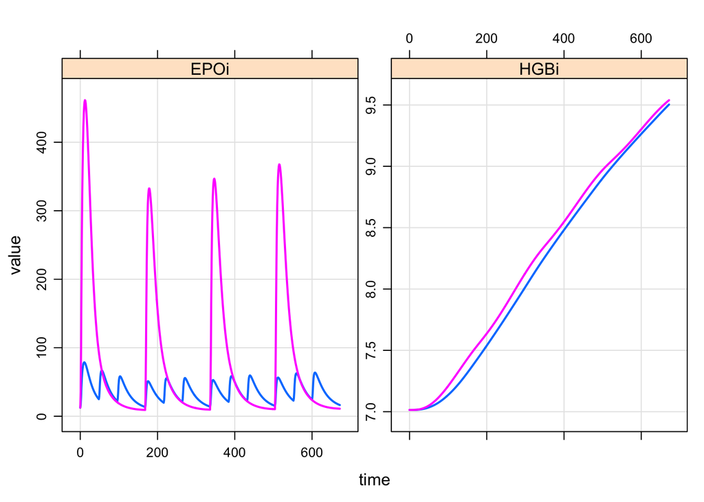

```r
mod %>%
  zero_re %>%
  mrgsim(data = data_sc, end = 672) %>%
  plot(EPOi + HGBi~.)
```

```r
data_sc
```

```
.   time cmt   amt rate evid  ii addl    ID
. 1    0   1  7000   -2    1 168    3  7000
. 2   48   1  7000   -2    1 168    3  7000
. 3   96   1  7000   -2    1 168    3  7000
. 4    0   1 40000   -2    1 168    3 40000
```

```r
data_iv <- mutate(data_sc, cmt = 2, rate = 0)
data_iv
```

```
.   time cmt   amt rate evid  ii addl    ID
. 1    0   2  7000    0    1 168    3  7000
. 2   48   2  7000    0    1 168    3  7000
. 3   96   2  7000    0    1 168    3  7000
. 4    0   2 40000    0    1 168    3 40000
```

## IV administration

- But when we look at the TIW versus QW comparison with IV administration, the once-weekly is less effective than three-times-weekly

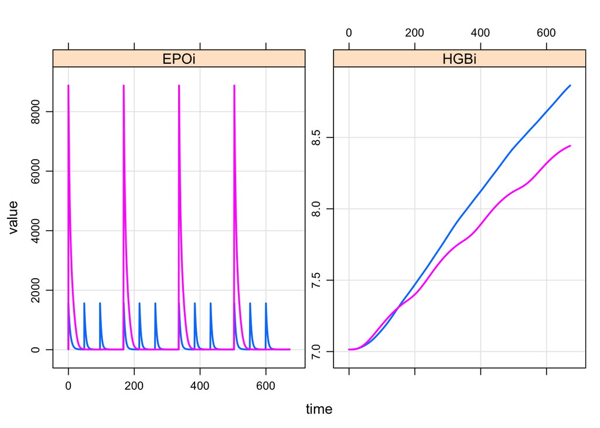

```r
mod %>%
  zero_re %>%
  mrgsim(data = data_iv, end = 672) %>%
  plot(EPOi + HGBi~.)
```

# Our task

Let’s look at the probability of technical success for the QW versus TIW dosing in the IV case

Let’s ramp this up for PTS

## Population data sets

TIW data

```r
iv_tiw <- ev_rep(tiw, id = 1:250) %>% mutate(cmt = 2, rate = 0)
```

```
. Warning in ev_rep(tiw, id = 1:250): id argument is deprecated; use ID
. instead
```

QW data

```r
iv_qw <- filter(iv_tiw, time==0) %>% mutate(amt = 40000, ID = ID + 1000)
```

If we bind this all together, we can simulate both regimens in one go

```r
data <- bind_rows(iv_tiw, iv_qw)

data
```

```
.      time cmt   amt rate evid  ii addl   ID
. 1       0   2  7000    0    1 168    3    1
. 2      48   2  7000    0    1 168    3    1
. 3      96   2  7000    0    1 168    3    1
. 4       0   2  7000    0    1 168    3    2
. 5      48   2  7000    0    1 168    3    2
. 6      96   2  7000    0    1 168    3    2
. 7       0   2  7000    0    1 168    3    3
. 8      48   2  7000    0    1 168    3    3
. 9      96   2  7000    0    1 168    3    3
. 10      0   2  7000    0    1 168    3    4
. 11     48   2  7000    0    1 168    3    4
. 12     96   2  7000    0    1 168    3    4
. 13      0   2  7000    0    1 168    3    5
. 14     48   2  7000    0    1 168    3    5
. 15     96   2  7000    0    1 168    3    5
. 16      0   2  7000    0    1 168    3    6
. 17     48   2  7000    0    1 168    3    6
. 18     96   2  7000    0    1 168    3    6
. 19      0   2  7000    0    1 168    3    7
. 20     48   2  7000    0    1 168    3    7
. 21     96   2  7000    0    1 168    3    7
. 22      0   2  7000    0    1 168    3    8
. 23     48   2  7000    0    1 168    3    8
. 24     96   2  7000    0    1 168    3    8
. 25      0   2  7000    0    1 168    3    9
. 26     48   2  7000    0    1 168    3    9
. 27     96   2  7000    0    1 168    3    9
. 28      0   2  7000    0    1 168    3   10
. 29     48   2  7000    0    1 168    3   10
. 30     96   2  7000    0    1 168    3   10
. 31      0   2  7000    0    1 168    3   11
. 32     48   2  7000    0    1 168    3   11
. 33     96   2  7000    0    1 168    3   11
. 34      0   2  7000    0    1 168    3   12
. 35     48   2  7000    0    1 168    3   12
. 36     96   2  7000    0    1 168    3   12
. 37      0   2  7000    0    1 168    3   13
. 38     48   2  7000    0    1 168    3   13
. 39     96   2  7000    0    1 168    3   13
```

[output cut: 72 more lines]

```
. 112     0   2  7000    0    1 168    3   38
. 113    48   2  7000    0    1 168    3   38
. 114    96   2  7000    0    1 168    3   38
. 115     0   2  7000    0    1 168    3   39
. 116    48   2  7000    0    1 168    3   39
. 117    96   2  7000    0    1 168    3   39
. 118     0   2  7000    0    1 168    3   40
. 119    48   2  7000    0    1 168    3   40
. 120    96   2  7000    0    1 168    3   40
. 121     0   2  7000    0    1 168    3   41
. 122    48   2  7000    0    1 168    3   41
. 123    96   2  7000    0    1 168    3   41
. 124     0   2  7000    0    1 168    3   42
. 125    48   2  7000    0    1 168    3   42
.  [ reached getOption("max.print") -- omitted 875 rows ]
```

- What about simulating some variatility in Weight?

A simulation function

Arguments

- `i` replicate number
- `mod` the EPO model object
- `data` a template data set

```r
sim <- function(i, mod, data) {

 mod <- param(mod, slice(post,i))

 out <- mrgsim(mod, data = data, obsonly = TRUE,
               end = -1, add = 672)

  mutate(out, irep = i, qw = as.integer(ID >= 1000))
}
```

Test it out

```r
sim(2, mod, data)
```

```
. # A tibble: 500 x 9
.       ID  time RETdv  EPOi  RETi  RBCi  HGBi  irep    qw
.    <dbl> <dbl> <dbl> <dbl> <dbl> <dbl> <dbl> <dbl> <int>
.  1     1   672 125.   6.74 106.   2.92  8.56     2     0
.  2     2   672  80.6  8.39 113.   2.72  8.72     2     0
.  3     3   672  81.3  6.96  76.4  2.68  8.05     2     0
.  4     4   672  84.3 11.0   92.7  3.02  9.63     2     0
.  5     5   672 149.   8.98 129.   3.29  9.69     2     0
.  6     6   672 124.   9.13 119.   2.98  9.17     2     0
.  7     7   672 106.   6.28 125.   3.04  9.27     2     0
.  8     8   672 122.   7.36 151.   3.09  9.04     2     0
.  9     9   672  71.1  9.20 104.   2.70  9.02     2     0
. 10    10   672 103.   8.16 101.   2.85  8.18     2     0
. # ... with 490 more rows
```

## Simulate

- Remember to set a seed
- And change the `RNGkind`
- What about uncertainty in the random effect variances?

```r
set.seed(10020)
mcRNG()
out <- parallel::mclapply(1:101, mc.cores = 8,
                          sim, mod, data) %>% bind_rows
```

## Summarize

Our target is HGB > 8.5

```r
sum1 <-
out %>%
  group_by(irep,qw) %>%
  summarise(success = mean(HGBi > 8.5))

sum1
```

```
. # A tibble: 202 x 3
. # Groups:   irep [?]
.     irep    qw success
.    <int> <int>   <dbl>
.  1     1     0   0.268
.  2     1     1   0.192
.  3     2     0   0.748
.  4     2     1   0.536
.  5     3     0   0.036
.  6     3     1   0.024
.  7     4     0   0.352
.  8     4     1   0.18
.  9     5     0   0.576
. 10     5     1   0.4
. # ... with 192 more rows
```

Our success criteria is at least 40% of patients hitting the target

```r
sum2 <-
  sum1 %>%
  group_by(qw) %>%
  summarise(PR = mean(success > 0.4))
```

The bottom line

```r
sum2
```

```
. # A tibble: 2 x 2
.      qw    PR
.   <int> <dbl>
. 1     0 0.604
. 2     1 0.287
```